# Tugas ARIMA Econometrics

## Arima test

```python
import pandas as pd
import matplotlib.pyplot as plt
from scipy import stats
import seaborn as sns
from scipy.stats import boxcox
from statsmodels.tsa.stattools import acf, pacf
from statsmodels.graphics.tsaplots import plot_acf
from statsmodels.graphics.tsaplots import plot_pacf
import statsmodels.api as sm
import itertools
import numpy as np
from statsmodels.tsa.arima.model import ARIMA
from statsmodels.tsa.stattools import adfuller
```

#### 1. Data Preprocessing

```python
#Import Data
df = pd.read_excel("C:/Users/Komang Juliantara/Downloads/Data Arima_fiks.xlsx",sheet_name = 1)
df_1 =  pd.read_excel("C:/Users/Komang Juliantara/Downloads/Data Arima_fiks.xlsx")
df.set_index('Tanggal', inplace=True)
df_1.set_index('Tanggal', inplace=True)
df
```

| Tanggal | Terakhir |
| --- | --- |
| 2013-12-01 | 2008.52 |
| 2014-01-01 | 2013.40 |
| 2014-02-01 | 1888.27 |
| 2014-03-01 | 1826.15 |
| 2014-04-01 | 1846.44 |
| ... | ... |
| 2024-02-01 | 2185.10 |
| 2024-03-01 | 2194.62 |
| 2024-04-01 | 2244.51 |
| 2024-05-01 | 2243.16 |
| 2024-06-01 | 2260.48 |

127 rows × 1 columns

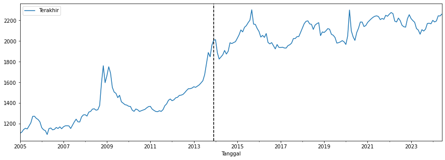

```python
#vissualization for original data
fig, ax = plt.subplots(figsize =(15,5))
df_1.plot(ax=ax, label = 'Original data')
ax.axvline('2013-12-01', color = 'black', ls = '--')
plt.show()
```

```python
#split data in to training and test
train = df.loc[df.index < '2021-05-01']
test = df.loc[df.index >= '2021-05-01']
```

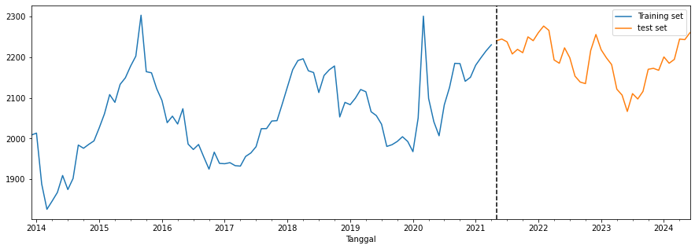

```python
fig, ax = plt.subplots(figsize =(15,5))
train.plot(ax=ax, label = 'Training set')
test.plot(ax=ax, label = 'test set')
ax.axvline('2021-05-01', color = 'black', ls = '--')
ax.legend(['Training set', 'test set'])
plt.show()
```

```python
#stasionary test
#Augmented Dickey-Fuller (ADF) Test
adf_result = adfuller(train)
print('ADF Statistic:', adf_result[0])
print('p-value:', adf_result[1])
print('Critical Values:')
for key, value in adf_result[4].items():
    print(f'   {key}: {value}')
```

```
ADF Statistic: -2.2718148294788323
p-value: 0.18121941542213893
Critical Values:
   1%: -3.506944401824286
   5%: -2.894989819214876
   10%: -2.584614550619835
```

[output not shown]

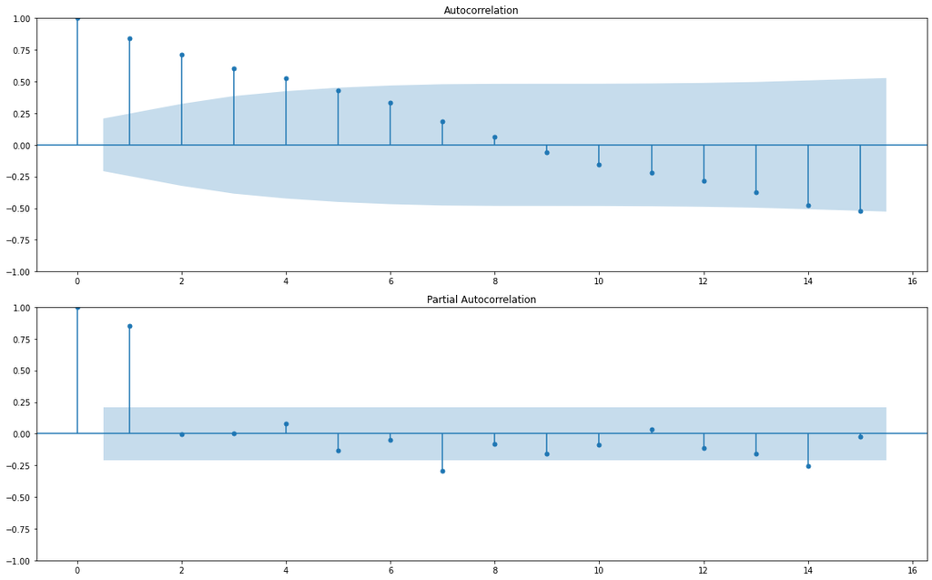

```python
#ACF and PACF Tets
f, ax = plt.subplots(nrows=2, ncols=1, figsize=(16,10))
plot_acf(train, lags=15, ax=ax[0])
plot_pacf(train, lags=15, ax=ax[1])

plt.tight_layout()
plt.show()
```

H0: there is unit root (non-stationary) H1: does not have a unit root (stationary)

reject h0 if p value less than 0.05

#### 2. Transformation Data

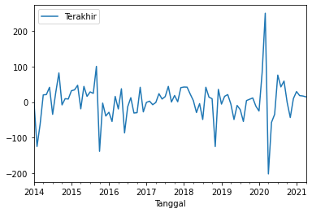

```python
#transform to stationary using differencing
New_Terakhir_diff = train.diff().dropna()
New_Terakhir_diff.plot()
```

```python
#adf test for the 1st transformation
adf_result = adfuller(New_Terakhir_diff)
print('ADF Statistic:', adf_result[0])
print('p-value:', adf_result[1])
print('Critical Values:')
for key, value in adf_result[4].items():
    print(f'   {key}: {value}')
```

```
ADF Statistic: -9.917384129416048
p-value: 3.054431167229402e-17
Critical Values:
   1%: -3.5078527246648834
   5%: -2.895382030636155
   10%: -2.584823877658872
```

since P value is less than 5%, reject null hypotesis. There is no evidence that the data is not stasioner and we can conlude that the arima model is (p,1,q)

#### 3. Model Identification

[output not shown]

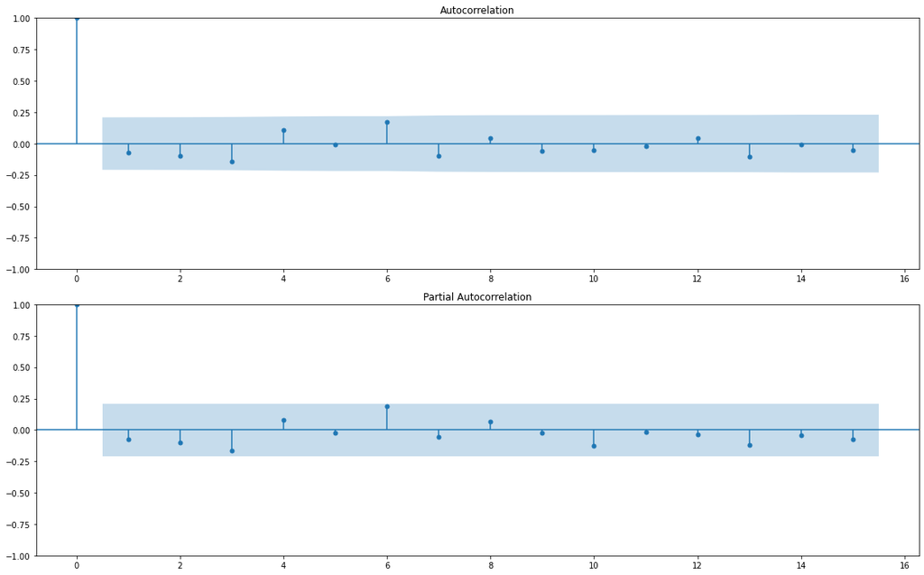

```python
f, ax = plt.subplots(nrows=2, ncols=1, figsize=(16,10))

plot_acf(New_Terakhir_diff, lags=15, ax=ax[0])
plot_pacf(New_Terakhir_diff, lags=15, ax=ax[1])

plt.tight_layout()
plt.show()
```

Since there are significant lags at index 0 for both ACF and PACF plot, we can assume that the ARIMA model is (0,1,0).

#### 4. Estimating Parameter and Model

```python
#find the best model of ARIMA
from statsmodels.tsa.arima_model import ARIMA
import pmdarima as pm

# get actual data for county Polk
data_actual = train

# set seasonal to True
seasonal = False

# use pmdarima to automatically select best ARIMA model
model = pm.auto_arima(data_actual,
                      m=24,               # frequency of series
                      seasonal=seasonal,  # TRUE if seasonal series
                      d=1,             # let model determine 'd'
                      test='adf',         # use adftest to find optimal 'd'
                      start_p=0, start_q=0, # minimum p and q
                      max_p=12, max_q=12, # maximum p and q
                      D=None,             # let model determine 'D'
                      trace=True,
                      error_action='ignore',
                      suppress_warnings=True,
                      stepwise=True)
```

[output not shown]

```
Performing stepwise search to minimize aic
 ARIMA(0,1,0)(0,0,0)[0] intercept   : AIC=955.837, Time=0.59 sec
 ARIMA(1,1,0)(0,0,0)[0] intercept   : AIC=957.372, Time=0.47 sec
 ARIMA(0,1,1)(0,0,0)[0] intercept   : AIC=957.236, Time=0.33 sec
 ARIMA(0,1,0)(0,0,0)[0]             : AIC=954.029, Time=0.04 sec
 ARIMA(1,1,1)(0,0,0)[0] intercept   : AIC=958.204, Time=0.51 sec

Best model:  ARIMA(0,1,0)(0,0,0)[0]
Total fit time: 2.087 seconds
```

the best model is arima(0,1,0) with the lowest AIC compared to other models

#### 5. Evaluation Model

```python
#AIC, BIC sCore and Ljung_Box test
model.summary()
```

SARIMAX Results

| Dep. Variable: | y | No. Observations: | 89 |
| --- | --- | --- | --- |
| Model: | SARIMAX(0, 1, 0) | Log Likelihood | -476.015 |
| Date: | Sun, 07 Jul 2024 | AIC | 954.029 |
| Time: | 12:34:47 | BIC | 956.506 |
| Sample: | 12-01-2013 | HQIC | 955.027 |
|  | - 04-01-2021 |  |  |
| Covariance Type: | opg |  |  |

|  | coef | std err | z | P>\|z\| | [0.025 | 0.975] |
| --- | --- | --- | --- | --- | --- | --- |
| sigma2 | 2923.7958 | 218.427 | 13.386 | 0.000 | 2495.686 | 3351.906 |

| Ljung-Box (L1) (Q): | 0.49 | Jarque-Bera (JB): | 139.22 |
| --- | --- | --- | --- |
| Prob(Q): | 0.49 | Prob(JB): | 0.00 |
| Heteroskedasticity (H): | 1.82 | Skew: | 0.05 |
| Prob(H) (two-sided): | 0.11 | Kurtosis: | 9.16 |

Warnings:  
[1] Covariance matrix calculated using the outer product of gradients (complex-step).

Ljung-box test H0 : Resdiual are white moise H0 : Resdiual are not white moise

reject H0 if p value less than 0.05 Since P value greater than 0.05, do not reject H0. There is evidence that there is no significant autocorrelation in the residuals, indicating that they resemble white noise.

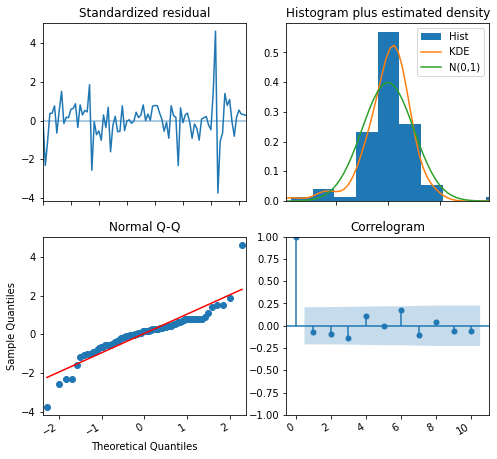

```python
# ACF residual Plot
fig = model.plot_diagnostics(figsize=(8, 8))
fig.autofmt_xdate()
plt.show()
```

#### 5. Forecasting

```python
Forcast = model.predict(n_periods=len(test)+12)
Forcast_1 = Forcast.iloc[len(test):]
print(Forcast_1)
```

```
2024-07-01    2230.46
2024-08-01    2230.46
2024-09-01    2230.46
2024-10-01    2230.46
2024-11-01    2230.46
2024-12-01    2230.46
2025-01-01    2230.46
2025-02-01    2230.46
2025-03-01    2230.46
2025-04-01    2230.46
2025-05-01    2230.46
2025-06-01    2230.46
Freq: MS, dtype: float64
```

#### 6. Data Validation

```python
predict_1 = pd.Series(model.predict(n_periods = len(test)))
k = predict_1
```

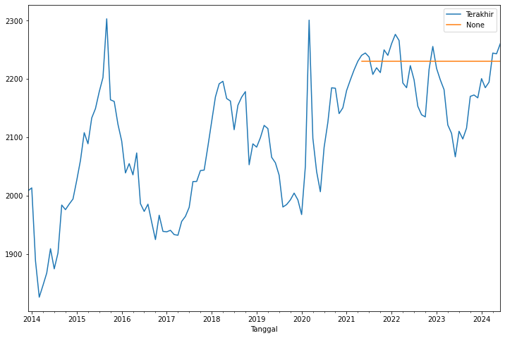

```python
df['Terakhir'].plot(figsize = (12,8), legend = True)
k.plot(legend = True)
```